# Example Open-ended Analysis

Author

Student Sample from Lab 4: Avocado Prices (Q7)

**7. In which California regions is the price of organic versus conventional avocados most different? Support your answer with a few summary statistics AND a visualization.**

**Note**

When not in a “lab format” you would provide some sort of **introduction** including a data description and recapping the research question.

Also describe any data cleaning steps that were taken and maybe briefly describe your “game plan” – what will I read about how you approached the problem?

```r
avocados_ca_mean <- avocados_ca |>
  group_by(geography, year, type) |>
  summarize(mean(average_price)) |>
  rename("Average_Price" = "mean(average_price)")
```

This visualization demonstrates the average cost of avocados for each region with the two avocado types getting a line as it fluctuates over the years. While the gaps between them are pretty similar it appears there is less of a difference in average cost between organic and conventional for Los Angeles and wider for San Fransico.

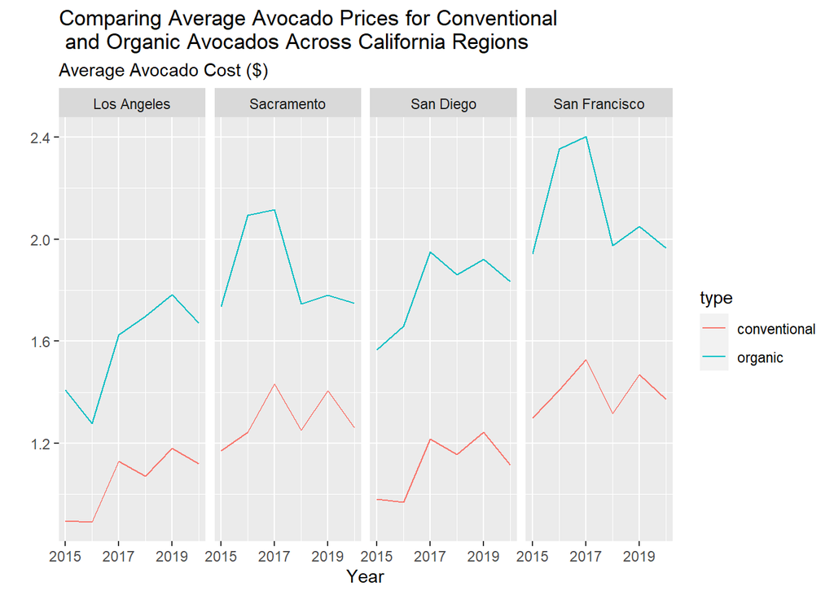

```r
ggplot(data = avocados_ca_mean, aes(x= year, y = Average_Price)) +
  labs(x = "Year", y = " " , subtitle = "Average Avocado Cost ($)", title  = "Comparing Average Avocado Prices for Conventional \n and Organic Avocados Across California Regions") +
  geom_line(aes(y = Average_Price, group = type, colour = type)) +
  scale_x_continuous(breaks=seq(2015,2021,by=2)) +
  facet_grid(~geography)
```

```r
#References:
# - https://stackoverflow.com/questions/57977108/geom-line-connect-specific-group-variables-with-different-line-types
# - https://www.tutorialspoint.com/how-to-set-the-y-axis-tick-marks-using-ggplot2-in-r#:~:text=The%20default%20value%20of%20Y,10%2Cby%3D1)).
```

Let’s Explore a metric that may be more conclusive.

This code chunk demonstrates that across the years, the average avocado price difference between organic and conventional avocados was most drastic in San Francisco.

```r
avocados_ca_con <- avocados_ca_mean |>
  filter(type == "conventional") |>
  group_by(geography) |>
  summarize(averagePriceCon = mean(Average_Price))

avocados_ca_org <- avocados_ca_mean |>
  filter(type == "organic") |>
  group_by(geography) |>
  summarize(averagePriceOrg = mean(Average_Price))

full_join(avocados_ca_con, avocados_ca_org) |>
  mutate(absDiff = abs(averagePriceOrg - averagePriceCon)) |>
  arrange(desc(absDiff))
```

```
# A tibble: 4 × 4
  geography     averagePriceCon averagePriceOrg absDiff
  <chr>                   <dbl>           <dbl>   <dbl>
1 San Francisco            1.40            2.12   0.716
2 San Diego                1.11            1.80   0.685
3 Sacramento               1.29            1.87   0.576
4 Los Angeles              1.05            1.58   0.529
```

The above data relatively ingores how price differences may fluctuate across years, so let’s visualize that fluctuation.

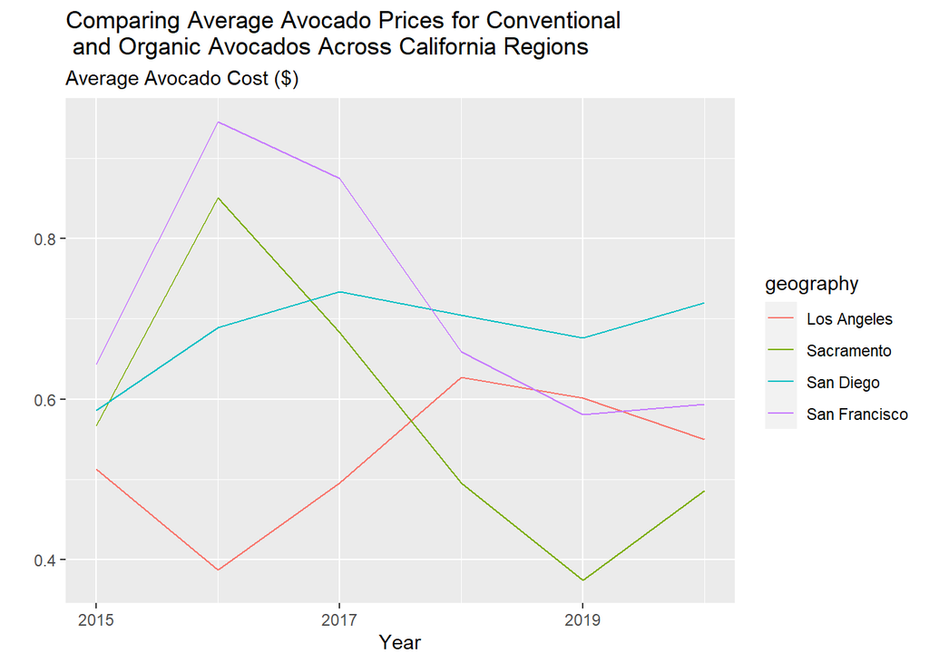

```r
avocados_ca_con <- avocados_ca_mean |>
  filter(type == "conventional") |>
  group_by(geography, year) |>
  summarize(averagePriceCon = mean(Average_Price))

avocados_ca_org <- avocados_ca_mean |>
  filter(type == "organic") |>
  group_by(geography, year) |>
  summarize(averagePriceOrg = mean(Average_Price))

full_join(avocados_ca_con, avocados_ca_org) |>
  mutate(absDiff = abs(averagePriceOrg - averagePriceCon)) |>
  arrange(desc(absDiff)) |>
  ggplot(aes(x= year, y = absDiff)) +
    labs(x = "Year", y = " " , subtitle = "Average Avocado Cost ($)", title  = "Comparing Average Avocado Prices for Conventional \n and Organic Avocados Across California Regions") +
    geom_line(aes(y = absDiff, group = geography, colour = geography)) +
    scale_x_continuous(breaks=seq(2015,2021,by=2))
```

**Warning**

Look at your plots and provide any addional customizations to improve their readability. We have learned a lot of skills for this in class including labels, colors, legend order, double encoding etc.

We have also learned about alternative plots options:

- **Visualizaing distributions?** 🙁 Box plots 😄 Ridge plots 😄 Violin plots
- **Plotting Averages?** 😐 Bar Plots 😄 Cleveland dot plots